# Biostat 276 Homework 1

### (g)

Use the algorithms in (a, b, c, d, e, f) to estimate the following quantities: $E(x^2_1)$,$E(x_2)$ and $Pr(x_1 + x_2 > 0)$. Discuss and quantify how different sampling strategies affect Monte Carlo variance.

```r
.summary_fun <- function(x1,x2,method){
  df_x1 <- c(mean(x1^2), sd(x1^2), quantile(x1^2, c(0.025, 0.975))) %>% round(2)
  df_x2 <- c(mean(x2), sd(x2), quantile(x2, c(0.025, 0.975))) %>% round(2)
  out <- rbind(df_x1, df_x2)
  out <- cbind(out, method=method)
  colnames(out)[c(1,2)] <- c("E", "sd")
  return(out)
}

df <- rbind(.summary_fun(x_q1,x_q2,method="a"),
            .summary_fun(x_AR[,1],x_AR[,2],method="b"),
            .summary_fun(x_IS[,1],x_IS[,2],method="c"),
            .summary_fun(mcmc.sim.d$x1,mcmc.sim.d$x2,method="d"),
            .summary_fun(mcmc.sim.e$x1,mcmc.sim.e$x2,method="e"),
            .summary_fun(mcmc.sim.f$x1,mcmc.sim.f$x2,method="f"))
df %>%
  kbl(caption = NULL) %>%
  kable_classic(full_width = F, html_font = "Cambria")
```

|  | E | sd | 2.5% | 97.5% | method |
| --- | --- | --- | --- | --- | --- |
| df_x1 | 0.99 | 1.41 | 0 | 5.03 | a |
| df_x2 | -8.02 | 2.98 | -11.45 | 0.13 | a |
| df_x1 | 1.25 | 1.58 | 0 | 5.4 | b |
| df_x2 | -7.45 | 3.3 | -11.46 | 0.55 | b |
| df_x1 | 1.2 | 1.54 | 0 | 5.45 | c |
| df_x2 | -7.54 | 3.25 | -11.31 | 0.67 | c |
| df_x1 | 0.91 | 1.13 | 0 | 3.94 | d |
| df_x2 | -8.2 | 2.43 | -11.49 | -1.45 | d |
| df_x1 | 0.68 | 0.85 | 0 | 3.19 | e |
| df_x2 | -8.69 | 1.94 | -11.52 | -3.65 | e |
| df_x1 | 0.69 | 0.77 | 0 | 2.72 | f |
| df_x2 | -8.62 | 1.84 | -11.49 | -4.16 | f |

As we can tell from the table, all methods provides consistent estimation of X1 and X2. Generally speaking, MCMC methods provided better (smaller) sample var. Among all methods, Gibbs sampling shows the smallest sample var. Iterative Metropolis Hastings algorithm performed better than the original one. AR method gave the largest sample var.

### (h)

For the estimation of the quantities in (vii), discuss at least two strategies that could be implemented for some of the algorithms to reduce Monte Carlo variance. Implement these strategies and quantify your improved estimators in a Monte Carlo study.

#### Antithetic Variates (for AR method)

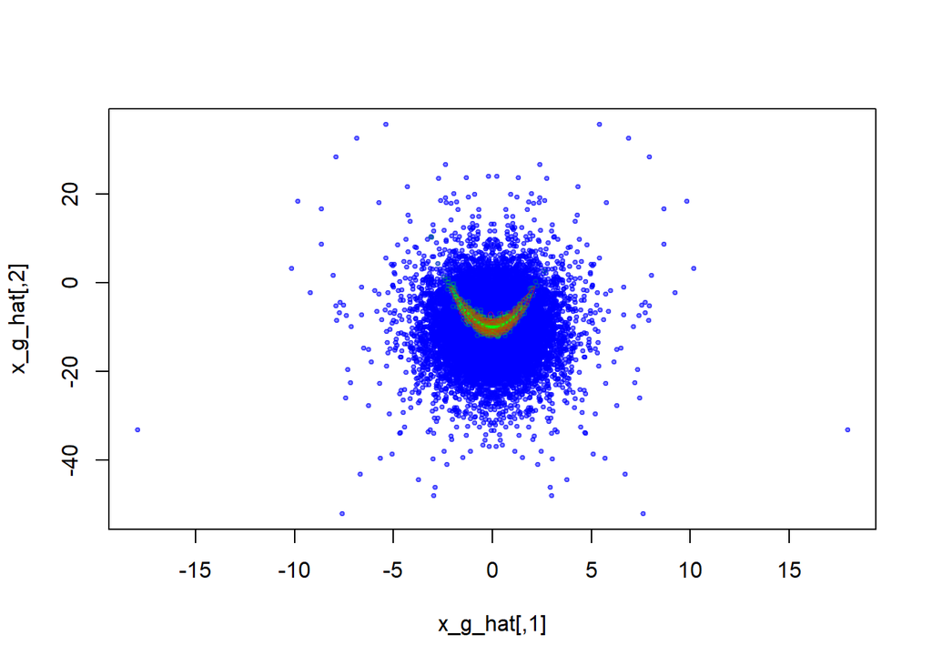

```r
set.seed(1996)
delta <- c(0, -10)
Sigma <- matrix(c(1,0.9,0.9,20),2,2)
nsim <- 15000
Sigma1 <- Sigma
nu <- 5

x_g1 <- rmvt(n = nsim, sigma = Sigma1, df = nu, delta = delta)
x_g2 <- cbind(-x_g1[,1], x_g1[,2])
x_g <- rbind(x_g1, x_g2)
#plot(x_g, col=rgb(0,0,1, alpha=0.5), pch=19, cex=0.5)
x_g_hat <- x_g[which(x_g[,1]>=0),]
x_g_hat <- rbind(x_g_hat, x_g_hat)
x_g_hat[(dim(x_g_hat)[1]/2+1):dim(x_g_hat)[1],1] <-
  -abs(x_g_hat[(dim(x_g_hat)[1]/2+1):dim(x_g_hat)[1],1])
nsim <- dim(x_g_hat)[1]

plot(x_g_hat, col=rgb(0,0,1, alpha=0.5), pch=19, cex=0.5)
#
# AR Sampling
#
g <- dmvt(x_g_hat, sigma=Sigma1, df=nu, delta=delta, log=FALSE)
#
fx <- rep(NA, nsim)
for(i in 1:nsim){
  temp1 <- x_g_hat[i,1]
  temp2 <- x_g_hat[i,2]
  fx[i] <- .banana(temp1, temp2)
}
f1 <- fx
M  <- 300
u  <- runif(nsim)
#
c1 <- f1/g * 1/M
x_AR_anti <- x_g_hat[c1 >= u,]
points(x_AR_anti,  col=rgb(0,1,0,alpha=0.2), cex=0.5)
contour(x1, x2, f, add=T, col=rgb(1,0,0,alpha=0.4))
```

```r
#compare improvement
df <- rbind(.summary_fun(x_AR[,1],x_AR[,2], method = "origin"),
            .summary_fun(x_AR_anti[,1],x_AR_anti[,2], method = "Antithetic"))
df %>%
  kbl(caption = NULL) %>%
  kable_classic(full_width = F, html_font = "Cambria")
```

|  | E | sd | 2.5% | 97.5% | method |
| --- | --- | --- | --- | --- | --- |
| df_x1 | 1.25 | 1.58 | 0 | 5.4 | origin |
| df_x2 | -7.45 | 3.3 | -11.46 | 0.55 | origin |
| df_x1 | 0.95 | 1.28 | 0 | 4.16 | Antithetic |
| df_x2 | -8.1 | 2.77 | -11.52 | -1 | Antithetic |

As we can tell from the results, Antithetic Variates improved the estimates (provided a smaller sample var).

#### Rao-Blackwell (for Gibbs)

Firstly, from part (a) we know that:

$P(x_2|x_1) \sim N(2(x_1^2-5), 1)$

Then we can generate a Rao-Blackwellized estimator for X_2. We can get that:

$E(x_2|x_1) = 2(x_1^2-5)$

```r
mcmc.sim.f$x2.rb <- 2*(mcmc.sim.f$x1^2-5)

#compare improvement
df <- rbind(.summary_fun(mcmc.sim.f$x1,mcmc.sim.f$x2, method = "origin"),
            .summary_fun(mcmc.sim.f$x1,mcmc.sim.f$x2.rb, method = "Rao-Blackwell"))
df %>%
  kbl(caption = NULL) %>%
  kable_classic(full_width = F, html_font = "Cambria")
```

|  | E | sd | 2.5% | 97.5% | method |
| --- | --- | --- | --- | --- | --- |
| df_x1 | 0.69 | 0.77 | 0 | 2.72 | origin |
| df_x2 | -8.62 | 1.84 | -11.49 | -4.16 | origin |
| df_x1 | 0.69 | 0.77 | 0 | 2.72 | Rao-Blackwell |
| df_x2 | -8.62 | 1.53 | -10 | -4.56 | Rao-Blackwell |

As we can tell from the results, Rao-Blackwell method improved the estimates (provided a smaller sample var).

## 2. Bayesian Adaptive Lasso

### (a)

Consider p = 1. Simulate 5,000 Monte Carlo samples from the conditional prior $\beta|\tau^2=1$ and obtain a plot of the density using the R function `density.`

We know that $\beta|\tau^2=1 \sim N_1(0,1)$. Apply AR method to generate $\beta$.

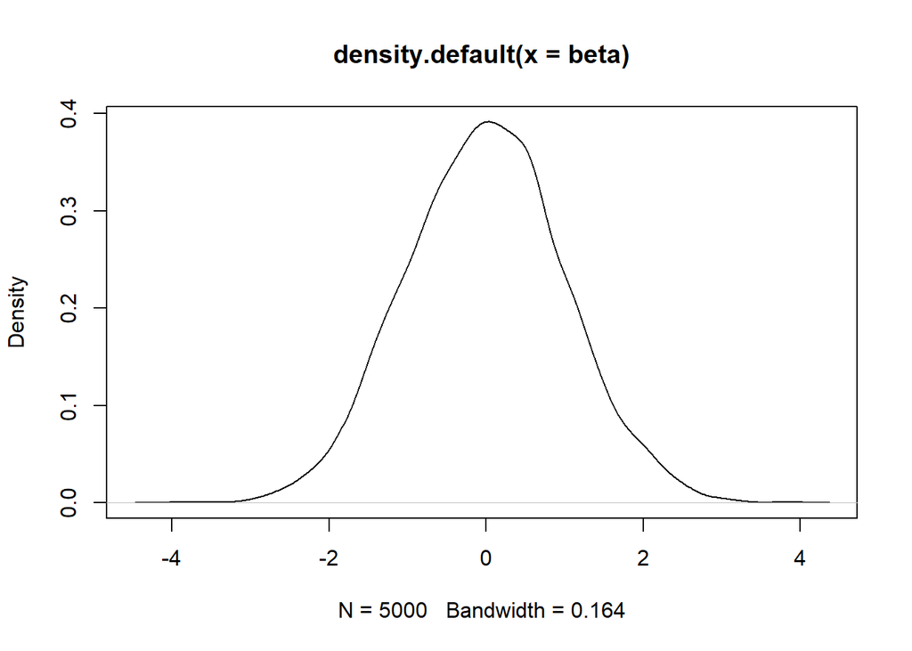

```r
set.seed(1996)
nsim <- 1000000
gx <- 1/100
M <- 100
x <- 100*runif(nsim)-50
fx <- dnorm(x)
u <- runif(nsim)
accept_beta <- x[u <= fx/(M*gx)]
beta <- accept_beta[1:5000]
density(beta) %>% plot()
```

### (b)

Consider p = 1. Simulate 5,000 Monte Carlo samples from the marginal prior $\beta$, considering $\lambda^2=2$, so that $E(\tau^2|\lambda) = 1$. Obtain a plot of the density as in a.

Since we know that $E(\tau^2|\lambda) = 1$, we know that $P(\tau^2|\lambda) = exp(-\tau^2)$. Then we use inverse transform method to simulate $\tau^2$ and then AR to simulate $\beta$.

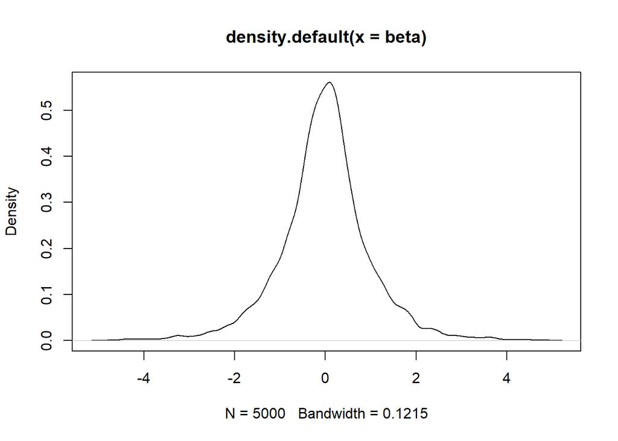

```r
set.seed(1996)
nsim <- 1000000
tau <- sqrt(-log(runif(nsim)))
gx <- 1/100
M <- 100
x <- 100*runif(nsim)-50
fx <- dnorm(x,0,tau)
u <- runif(nsim)
accept_beta <- x[u <= fx/(M*gx)]
beta <- accept_beta[1:5000]
density(beta) %>% plot()
```

### (c)

Consider p = 1. Add a hyper prior on $\lambda^2\sim Gamma(a,rate=b)$. Assess how the marginal prior of $\beta$ changes for $a = 1$ and values of $b\geq1$. (note that here we use $\lambda^2\sim Gamma(a,rate=b)$ rather than $1/\lambda^2\sim Gamma(a,rate=b)$ because of the convenience of calculation in the following part).

We know that Exponential(b) = Gamma(1,b). Then we use inverse transform to generate gamma(1,b).

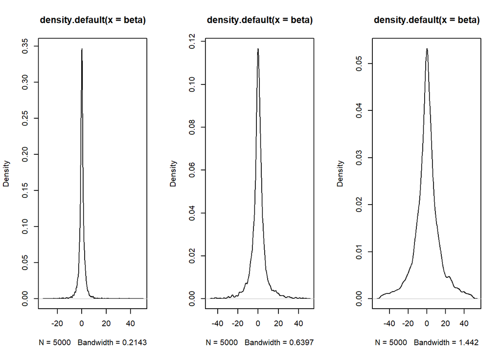

```r
set.seed(1996)
par(mfrow=c(1,3))

for(b in c(1,10,50)){
  lambda_sq <- -1/b*log(runif(nsim))
  tau <- sqrt(-2/lambda_sq*log(runif(nsim)))
  gx <- 1/100
  M <- 100
  x <- 100*runif(nsim)-50
  fx <- dnorm(x,0,tau)
  u <- runif(nsim)
  accept_beta <- x[u <= fx/(M*gx)]
  beta <- accept_beta[1:5000]
  density(beta) %>% plot()
}
```

We can tell from the plot that when $b$ increases, $\beta$ gets more dispersed.

### (d)

Considering the hyper prior in c., describe a Markov Chain Monte Carlo algorithm to sample from the posterior distribution of $\beta$ and $\sigma^2$.

As for $\beta$, we know that

$$\begin{array}{lcl}
P(\beta|Y,\sigma^2,\tau^2,\lambda) &=& P(\beta|Y,\sigma^2,\tau^2)\\
&\propto & P(Y|\beta,\sigma^2)*P(\beta|\tau^2)\\
&\propto & \exp(-\frac{1}{2\sigma^2}*(Y-X\beta)^{'}(Y-X\beta))*\exp(-\frac{1}{2\tau^2}*\beta^{'}\beta)\\
&=& \exp(-\frac{1}{2\sigma^2}(\beta^{'}*X^{'}X\beta-2*\beta X^{'}Y)-\frac{1}{2\tau^2}*\beta^{'}\beta)\\
&=& \exp(-\frac{1}{2}(\beta^{'}(\frac{X^{'}X}{\sigma^2}+\frac{1}{\tau^2}I)\beta-\frac{2}{\sigma^2}*\beta X^{'}Y))
\end{array}$$

This is a normal kernel. Then we found that $\beta|Y,\sigma^2,\tau^2,\lambda\sim N(\frac{ X^{'}Y}{X^{'}X+\frac{\sigma^2}{\tau^2}}, \frac{1}{\frac{X^{'}X}{\sigma^2}+\frac{1}{\tau^2}})$.

Then, for $\tau^2$, we know that

$$\begin{array}{lcl}
P(\tau_j^2|Y,\sigma^2,\beta_j,\lambda^2) &=& P(\tau^2|\lambda^2,\beta_j)\\
&=& P(\beta_j|\tau_j^2,\lambda^2)P(\tau_j^2|\lambda^2)\\
&\propto & 1/\sqrt{(\tau_j^2)}*\exp(-\frac{(\beta_j)^2}{2*\tau_j^2})\exp(-\frac{\lambda^2}{2}\tau_j^2)\\
&=&(\tau_j^2)^{-1/2}*\exp(-\frac{\beta_j^2}{2*\tau_j^2}-\frac{\lambda^2}{2}\tau_j^2)
\end{array}$$
This is inverse gaussian kernel. Then we know that $\tau_j^2|Y,\sigma^2,\beta_j,\lambda^2\sim InvGaussian(mean=\sqrt{\frac{\beta_j^2}{\tau_j^2}}, shape=\lambda^2)$

Then we can find the density for $\frac{1}{\tau_j^2}$,

$$\begin{array}{lcl}
P(\frac{1}{\tau_j^2}|Y,\sigma^2,\beta_j,\lambda^2)&\propto & (\frac{1}{\tau_j^2})^{1/2}*\exp(-\frac{\beta_j^2}{2}*\frac{1}{\tau_j^2}-\frac{\lambda^2}{2\frac{1}{\tau_j^2}})*|-(\frac{1}{\tau_j^2})^{-2}|\\
&=&(\frac{1}{\tau_j^2})^{-3/2}\exp(-\frac{\lambda^2}{2}(\frac{\beta_j^2}{\lambda^2}*\frac{1}{\tau_j^2}+(\frac{1}{\tau_j^2})^{-1}))
\end{array}$$

This is the kernel of inverse gaussian distribution. Then we found that $\frac{1}{\tau_j^2}\sim InvGaussian(mean=\sqrt{\frac{\lambda^2}{\beta_j^2}},shape=\lambda^2)$

As for $\lambda^2$,
$$\begin{array}{lcl}
P(\lambda^2|\tau^2,Y,\sigma^2,\beta_j) &\propto & (\lambda^2)^{a-1}\exp(-b\lambda^2)(\frac{2}{\lambda^2})^p\exp(-\frac{\lambda^2}{2}\sum\tau_j^2)\\
&\propto &(\lambda^2)^{a+p-1}\exp(-\lambda^2(b+\frac{1}{2}\sum\tau_j^2))
\end{array}$$

Then we know $\lambda^2|\tau^2,Y,\sigma^2,\beta_j\sim Gamma(a=1+10, b+\frac{1}{2}\sum\tau_j^2)$.

As for $\sigma^2$, we know that

$$\begin{array}{lcl}
P(\sigma^2|Y,\tau^2,\beta,\lambda^2) &=& P(\sigma^2|Y,\beta)\\
&\propto & P(Y|\beta,\sigma^2)*P(\sigma^2)\\
&\propto & (2\pi*\sigma^2)^{-\frac{n}{2}}\exp(-\frac{1}{2\sigma^2}*(Y-X\beta)^{'}(Y-X\beta))*(\sigma^2)^{-a-1}\exp(-\frac{b}{\sigma^2})\\
& = & (\sigma^2)^{-a-\frac{n}{2}-1}*\exp(-\frac{1/2*(Y-X\beta)^{'}(Y-X\beta)+b}{\sigma^2})
\end{array}$$

This is an Inverse Gamma kernel. Then we found that $\sigma^2|Y,\beta \sim InvGamma(0.1+\frac{n}{2},1/2*(Y-X\beta)^{'}(Y-X\beta)+10)$

After obtaining conditional posterior distributions for all parameters, we can apply Markov Chain Monte Carlo (Gibbs) algorithm to sample $\beta$ and $\sigma^2$.

### (e)

Implement such algorithm in R and compare your results with estimates obtained using `glmnet`(). In particular, you should test your results on the diabetes data available from `lars`, (use the matrix of predictors x).

```r
data("diabetes")
dia_x <- diabetes$x
dia_y <- diabetes$y
initial_value <- list(tau_sq=rep(10,10),
                      beta=rep(0,10),
                      sigma_sq=0.01,
                      lambda_sq=1)
mcmc.sim.gibbs <- function(initial_value, reg_path=F,
                           nsim=1000, burn=0, a=1, b=2,
                           X=dia_x, Y=dia_y, seed=199609){
  set.seed(seed)
  nsim.total <- nsim*(1.0 + burn)
  burn.num <- nsim*burn

  tau_sq <- initial_value$tau_sq
  beta <- initial_value$beta
  sigma_sq <- initial_value$sigma_sq
  lambda_sq <- initial_value$lambda_sq

  beta.ch <- matrix(NA,nsim,10)
  bmean.ch <- matrix(NA,nsim,10)
  tau_sq.ch <- matrix(NA,nsim,10)
  sigma_sq.ch <- vector()
  lambda_sq.ch <- vector()

  for(i in 1:nsim.total){
    #i=2
    #beta
    bmean <- solve(t(X)%*%X+diag(sigma_sq/tau_sq))%*%t(X)%*%Y
    bvar <- solve(t(X)%*%X/sigma_sq+diag(1/tau_sq))
    beta <- rmvnorm(n=1, mean = bmean, sigma = bvar)

    #lambda_sq
    if(reg_path==T){
      lambda_sq <- lambda_sq
    }else{
      lambda_sq <- rgamma(1, a+10, rate = b+sum(tau_sq)/2)
    }

    #sigma_sq
    sigma_sq <- 1/rgamma(1,shape = 0.1+221,
                         rate = 1/2*t(Y-X%*%t(beta))%*%(Y-X%*%t(beta))+10)

    #tau_sq
    tau_sq <- apply(matrix(beta),1,function(x){
      out <- rinvgauss(1, mean = sqrt(lambda_sq/x^2), shape = lambda_sq)
      return(1/out)
    })

    if(i > burn.num){
      i1 <- i - burn.num
      bmean.ch[i1,] <- bmean
      beta.ch[i1,] <- beta
      sigma_sq.ch[i1] <- sigma_sq
      tau_sq.ch[i1,] <- tau_sq
      lambda_sq.ch[i1] <- lambda_sq
    }
  }
  return(list(beta=beta.ch, sigma_sq=sigma_sq.ch, tau_sq=tau_sq.ch))
}

results_gibbs <- mcmc.sim.gibbs(initial_value, nsim=10000, burn=0.5, b=2)
```

check results

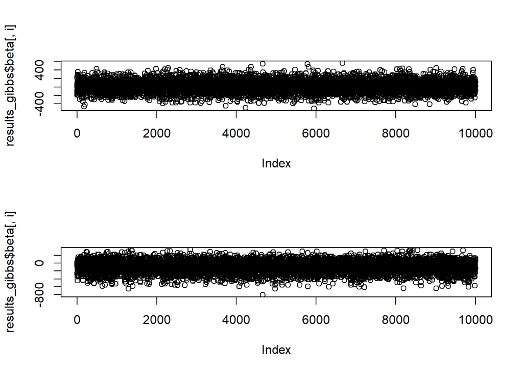

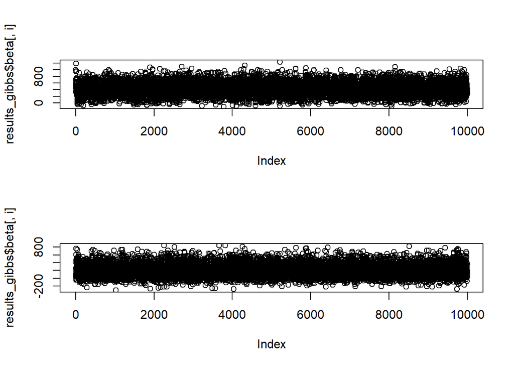

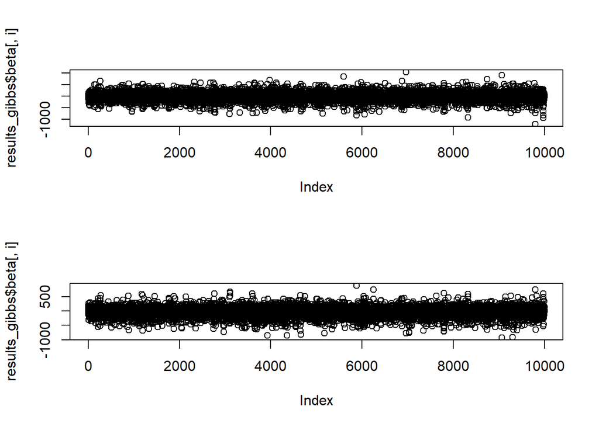

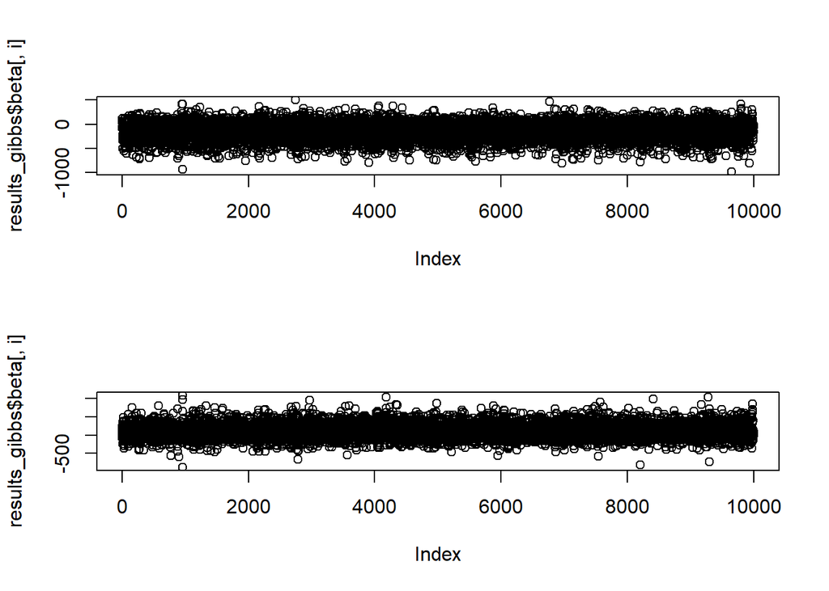

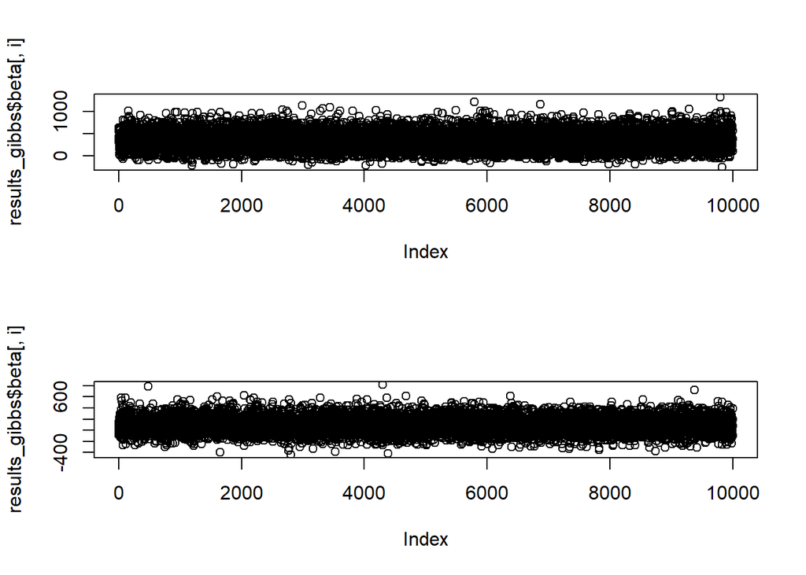

```r
par(mfrow=c(2,1))
for(i in 1:10){
  plot(results_gibbs$beta[,i])
}
```

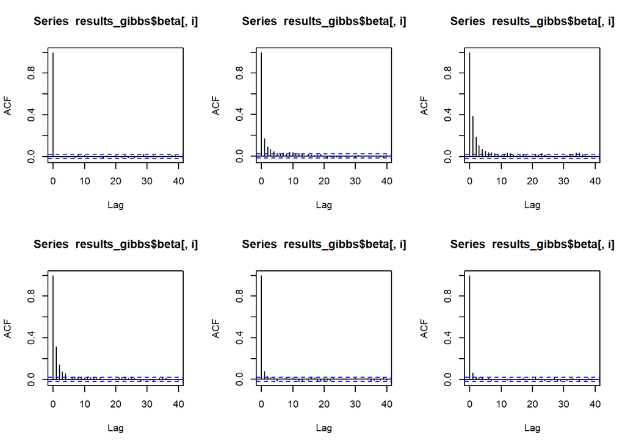

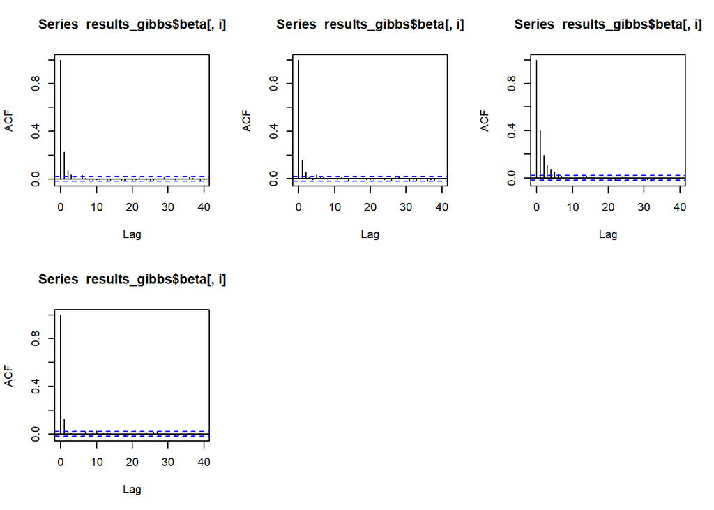

```r
par(mfrow=c(2,3))
for(i in 1:10){
  acf(results_gibbs$beta[,i])
}
```

We can tell from the plots that the algorithm converged well.

Apply `glmnet` function to obtain estimators (using elastic net).

```r
library(MASS)
library(glmnet)
fit.lasso <- glmnet(dia_x, dia_y)
cvfit <- cv.glmnet(dia_x, dia_y)
coef(cvfit, s = "lambda.min")
```

```
## 11 x 1 sparse Matrix of class "dgCMatrix"
##                      1
## (Intercept)  152.13348
## age            .
## sex         -220.78374
## bmi          525.78823
## map          310.97637
## tc          -175.07730
## ldl            .
## hdl         -169.42518
## tch           82.55659
## ltg          526.57119
## glu           62.66858
```

```r
df <- apply(results_gibbs$beta, 2,
            function(x){round(quantile(x,c(0.025,0.5,0.975)),2)})
colnames(df) <- colnames(dia_x)
df %>%
  kbl(caption = NULL) %>%
  kable_classic(full_width = T, html_font = "Cambria")
```

|  | age | sex | bmi | map | tc | ldl | hdl | tch | ltg | glu |
| --- | --- | --- | --- | --- | --- | --- | --- | --- | --- | --- |
| 2.5% | -223.71 | -374.58 | 62.50 | -59.16 | -370.72 | -388.68 | -506.02 | -215.13 | -5.60 | -161.59 |
| 50% | 13.71 | -66.46 | 422.49 | 191.12 | -8.48 | -21.48 | -114.23 | 72.18 | 341.91 | 64.39 |
| 97.5% | 260.02 | 143.61 | 803.92 | 548.23 | 298.52 | 247.64 | 143.03 | 491.14 | 770.57 | 370.16 |

```r
results_gibbs$sigma_sq %>% quantile(.,c(0.025,0.5,0.975))
```

```
##     2.5%      50%    97.5%
## 23377.36 26612.42 30354.64
```

As we can tell from the results, beta estimated by Bayesian Adaptive Lasso method and glmnet method are largely consistent.

### (f)

For the diabetes data, fix $\lambda$ and produce a regularization path for adaptive Bayesian Lasso obtained on a grid of values for the tuning parameter $\lambda$ . Describe your approach and compare your result with the path obtained using `glmnet`().

```r
lambda_sq_grid <- data.frame(lambda_sq=exp(seq(-12,0,0.3))^2)

start_time <- Sys.time()
test <- apply(lambda_sq_grid, 1,
              function(lambda_sq){
                initial_value$lambda_sq <- lambda_sq
                return(mcmc.sim.gibbs(initial_value,nsim=5000,
                                      burn=0.5, b=2, reg_path=T))})
saveRDS(test, "regularization_path.rds")
end_time <- Sys.time()
end_time - start_time
```

```
## Time difference of 3.102787 mins
```

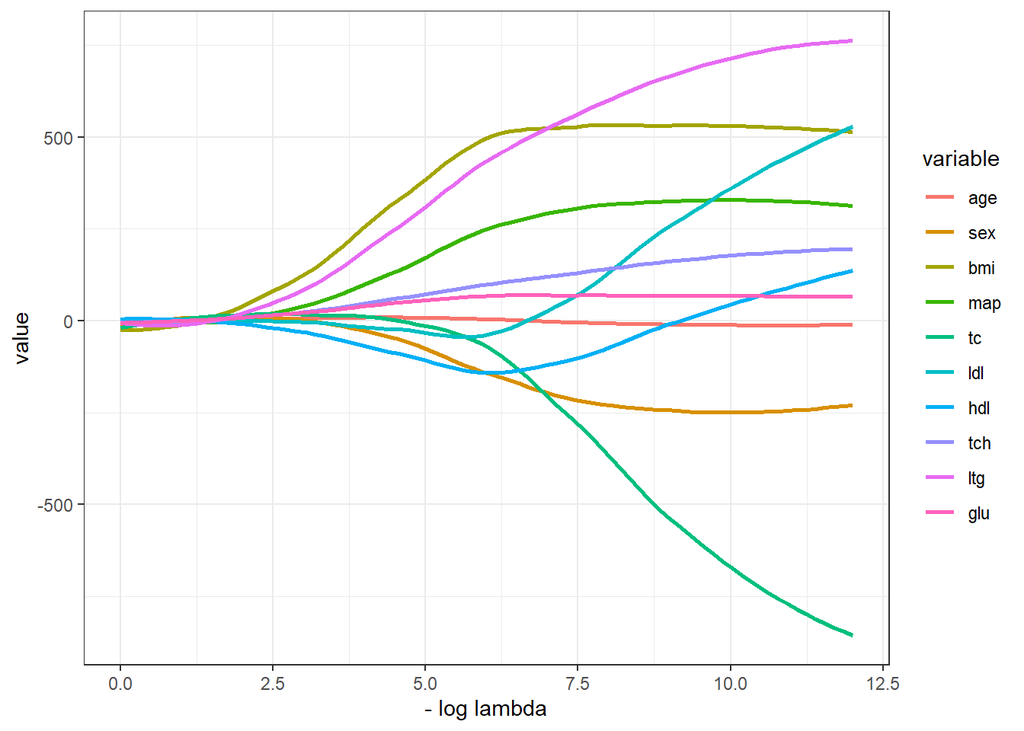

```r
test <- readRDS("regularization_path.rds")
results <- lapply(test, function(x){apply(x$beta,2,median)})
results_plot <- data.frame(Reduce("rbind", results))
colnames(results_plot) <- colnames(dia_x)
results_plot$lambda <- log(sqrt(lambda_sq_grid$lambda_sq))
results_plot <- melt(results_plot, id.vars = names(results_plot)[11])
ggplot(results_plot, aes(-lambda, value, color=variable)) +
  #geom_point()+
  geom_smooth(method = loess, se = FALSE) +
  labs(x = "- log lambda")+
  theme_bw()
```

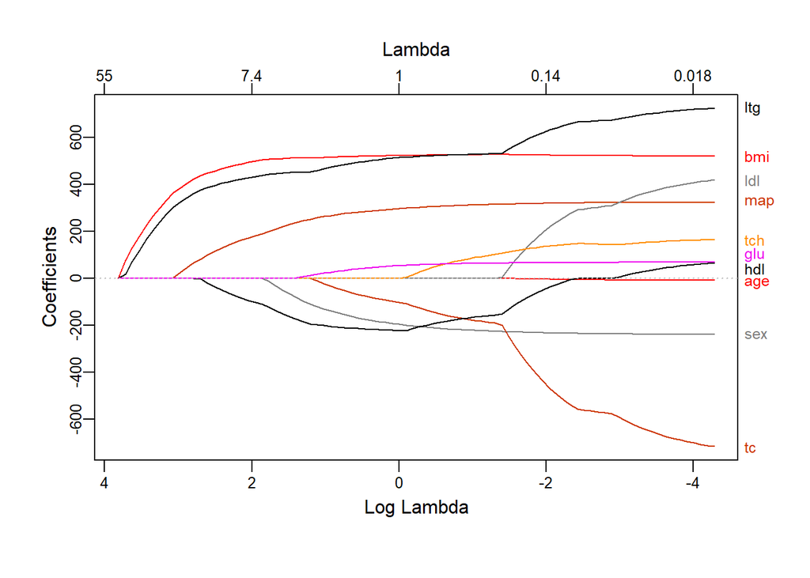

```r
plot_glmnet(fit.lasso)
```

As we can tell from the regularization path, beta estimated by Bayesian Adaptive Lasso method and `glmnet` method are largely consistent. The corresponding $\lambda$ for regularization path is different with that from `glmnet` method. The possible reason is that we use a slightly different way to parameterize the prior of $\beta$ ($\beta|\tau\sim N(0, D_{\tau})$ rather than $\beta|\tau\sim N(0, \sigma^2D_{\tau})$).

### (g)

Free $\lambda$ and carry out a sensitivity analysis assessing the behavior of the posterior distribution of $\beta$ and $\sigma^2$, as hyper parameters $a$ and $b$ are changed. Explain clearly the rationale you use to assess sensitivity and provide recommendations for the analysis of the diabetes data.

To conduct sensitivity analysis, we prepare several value pairs of a and b.

```r
(df_sen <- data.frame(a=c(1,1,1,2,5,2),
                     b=c(1,5,10,1,1,2)))
```

```
##   a  b
## 1 1  1
## 2 1  5
## 3 1 10
## 4 2  1
## 5 5  1
## 6 2  2
```

```r
start_time <- Sys.time()
test <- apply(df_sen, 1,
              function(sen){
                return(mcmc.sim.gibbs(initial_value, nsim=5000, burn=0.3,
                                      a=sen[1], b=sen[2]))})
saveRDS(test, "sensitivity_analysis.rds")
end_time <- Sys.time()

test <- readRDS("sensitivity_analysis.rds")
results_beta <- lapply(test,
                       function(x){apply(x$beta,2,
                                         function(beta){
                                           quantile(beta,c(0.025, 0.5, 0.975))}
                                         )})
results_sigma_sq <- lapply(test, function(x){apply(x$sigma_sq %>% as.matrix,2,
                                          function(sigma_sq){
                                            quantile(sigma_sq,c(0.025,0.5,0.975))}
                                          )})
results_ci_beta <- data.frame(Reduce("rbind", results_beta))
results_ci_sigma_sq <- data.frame(Reduce("rbind", results_sigma_sq))
results_ci <- cbind(results_ci_beta, results_ci_sigma_sq)
colnames(results_ci) <- c(colnames(dia_x), "sigma_sq")

df_compare <- matrix(NA, 11, 6)
for(i in 0:5){
  for(j in 1:11){
    df_compare[j,i+1] <- paste0(round(results_ci[3*i+2,j],2),"(",
                              round(results_ci[3*i+1,j],2), ", ",
                              round(results_ci[3*i+3,j],2), ")")
  }
}
rownames(df_compare) <- c(colnames(dia_x), "sigma_sq")
colnames(df_compare) <- paste0("a = ", df_sen$a, ", b = ", df_sen$b)
df_compare %>%
  kbl(caption = "Sensitivity Analysis") %>%
  kable_classic(full_width = T, html_font = "Cambria")
```

Sensitivity Analysis

|  | a = 1, b = 1 | a = 1, b = 5 | a = 1, b = 10 | a = 2, b = 1 | a = 5, b = 1 | a = 2, b = 2 |
| --- | --- | --- | --- | --- | --- | --- |
| age | 10.8(-220.1, 261.71) | 10.8(-220.1, 261.71) | 10.79(-220.1, 261.72) | 0(-2.6, 2.8) | 0(-1.42, 1.53) | 0(-3.66, 3.98) |
| sex | -65.82(-393.25, 148.3) | -65.83(-393.25, 148.3) | -65.83(-393.26, 148.31) | 0.01(-2.88, 2.82) | 0.01(-1.49, 1.54) | 0.01(-4.15, 4.01) |
| bmi | 433.2(61.17, 801.18) | 433.2(61.17, 801.19) | 433.21(61.17, 801.21) | 0.04(-2.61, 2.83) | 0.01(-1.49, 1.51) | 0.07(-3.64, 4.11) |
| map | 194.04(-57.28, 552.7) | 194.04(-57.28, 552.71) | 194.04(-57.28, 552.72) | 0.02(-2.62, 2.85) | 0.02(-1.52, 1.57) | 0.04(-3.66, 4.12) |
| tc | -13.15(-368.98, 301.52) | -13.16(-369, 301.53) | -13.16(-369.01, 301.53) | -0.01(-2.7, 2.78) | -0.01(-1.39, 1.45) | 0(-3.77, 3.96) |
| ldl | -22.35(-374.23, 258.55) | -22.36(-374.23, 258.56) | -22.36(-374.24, 258.57) | 0.01(-2.61, 2.92) | 0(-1.44, 1.51) | 0.02(-3.66, 4.11) |
| hdl | -112.38(-519.57, 137.93) | -112.39(-519.6, 137.94) | -112.39(-519.63, 137.94) | 0(-2.82, 2.53) | -0.01(-1.51, 1.45) | -0.01(-4.1, 3.51) |
| tch | 68.6(-222.88, 479.84) | 68.6(-222.89, 479.85) | 68.6(-222.9, 479.85) | 0(-2.67, 2.83) | 0(-1.55, 1.51) | 0(-3.78, 4.09) |
| ltg | 344.54(-2.97, 783.51) | 344.56(-2.97, 783.52) | 344.57(-2.96, 783.53) | 0(-2.67, 2.84) | 0.01(-1.52, 1.62) | 0.01(-3.65, 4.17) |
| glu | 67.52(-168.86, 373.71) | 67.52(-168.86, 373.71) | 67.52(-168.87, 373.71) | 0.03(-2.7, 3.01) | 0.01(-1.47, 1.46) | 0.05(-3.76, 4.32) |
| sigma_sq | 26550.58(23277.57, 30448.05) | 26550.55(23277.57, 30448.06) | 26550.5(23277.56, 30448.08) | 29103.98(25576.98, 33314.72) | 29087.21(25569.9, 33224.14) | 29104.9(25577.55, 33319.42) |

As we can tell from the table, changing of parameter $a$ will heavily affect the estimate of $\beta$, while the value of $b$ have little effects. Thus we need to fix $a=1$. As for $b$, I will recommend to use $b=10$ because it gives a more vague (dispersed) prior of $\lambda$ and allow observations to provide more information.